# Visualizing Plastics: Deliverable from Data

Author

Nathan Lee, Noah Nayve, Ryan Ekdahl, Taiga Sobajima

# Data Context

### Plastic (Main Data Set)

The main data set comes from Sarah Sauve, who conducted an audit based on Break Free from Plastic (BFFP), a global organization that runs annual brand audits. In these audits, volunteers around the world collect and report plastic waste. This makes the data set observational, as it relies on self-reported data submitted by volunteers each year, specifically for 2019 and 2020 in this case. However, the exact methods used by each volunteer is unknown. Each observation represents the plastic collected from a specific parent company within a given country and year. Here, Sauve intends to utilize this data set to raise plastic pollution awareness and highlight its importance. We are further supporting Sauve with our own analysis on two research questions presented later in this deliverable.

Below is a breakdown of all the variables in this data set:

- country (character): country of cleanup
- year (double): year, either 2019 or 2020
- parent_company (character): source of plastic
- empty (double): plastics counted without a brand being recorded
- hdpe (double): high density polyethylene count (i.e. plastic milk containers, plastic bags, bottle caps, trash cans, oil cans, plastic lumber, toolboxes, supplement containers)
- ldpe (double): low density polyethylene count (i.e. plastic bags, Ziploc bags, buckets, squeeze bottles, plastic tubes, chopping boards)
- o (double): other counts
- pet (double): polyester plastic count (i.e. polyester fibers, soft drink bottles, food containers)
- pp (double): polypropylene count (i.e. flower pots, bumpers, car interior trim, industrial fibers, carry-out beverage cups, microwavable food containers, DVD keep cases)
- ps (double): polystyrene count (i.e. toys, video cassettes, ashtrays, trunks, beverage/food coolers, beer cups, wine and champagne cups, carry-out food containers, Styrofoam)
- pvc (double): PVC plastic count (window frames, bottles for chemicals, flooring, plumbing pipes)
- grand_total (double): grand total count (all types of plastic)
- num_events (double): number of counting events
- volunteers (double): number of volunteers

Before combining two CSV files, the 2019 and 2020 data, some data cleaning steps were implemented. The 2019 CSV had two columns for “pp” (Polypropylene) and “ps” (Polystyrene) counts, so the repeated columns were combined to make one overall column for each variable. The data type of the “grand_total” column from the 2020 CSV was changed from character to numeric. Lastly, some variables were renamed to match one another, ensuring no errors when combining the two CSV files.

However, this data set has important limitations and potential inconsistencies to consider. The data depends on where volunteers are located, meaning it is more likely to be collected in accessible areas, which can lead over or under representation in some regions and introduce biased decisions. Due to the nature of self-reported data, there is no way for us to verify the data, nor see the differences in recognition between places. There may also be variability in how the plastic data is classified and reported to BFFP despite clear definitions.

# Preparing Data

### Loading in Libraries

```r
library(tidyverse)
library(glue)
```

### Reading Data Sets

```r
plastics <- read_csv('https://raw.githubusercontent.com/rfordatascience/tidytuesday/main/data/2021/2021-01-26/plastics.csv')
```

# Research Questions

1. so Do countries with more volunteers tend to collect more proportions of both high and low density polyethylene plastic in 2019 and 2020?
2. Do countries with greater forest coverage and more threatened species show a different breakdown of plastic types?

# Summaries and Visualizations

### Question 1

This custom function “plastic_volunteer_summary” finds volunteer and polyethylene plastic statistics based on an inputted polyethylene plastic type and country name. The default data set input is the main, plastic data set.

```r
plastic_volunteer_summary <- function(polyethylene, country_name, data = plastics) {
  # check to see if polyethylene and country_name is in the data frame
  if (
    !(polyethylene %in% c("ldpe", "hdpe"))
    ) {
    stop(
      paste("Plastic type not found or is not polyethylene kind:", polyethylene)
      )
    }

  if (
    !(country_name %in% data$country)
    ) {
    stop(
      paste("Country not found:", country_name)
      )
    }

  # setting column names for output
  avg_col <- glue("avg_{polyethylene}")
  percent_col <- glue("percent_{polyethylene}")
  total_col <- glue("total_{polyethylene}")

  # main body finding summary stats of volunteer and plastic type
  result <- data |>
    filter(country == country_name) |>
    mutate(percent_plastic_type = .data[[polyethylene]] / grand_total) |>
    summarise(
      !!avg_col := mean(.data[[polyethylene]], na.rm = TRUE),
      !!percent_col := sum(percent_plastic_type, na.rm = TRUE) /
                        sum(!is.na(percent_plastic_type)) * 100,
      !!total_col := sum(grand_total, na.rm = TRUE),
      avg_volunteers = mean(volunteers, na.rm = TRUE),
      total_volunteers = sum(volunteers, na.rm = TRUE)
    ) |>
    mutate(
      across(where(is.numeric), ~round(., 2)),
      !!percent_col := paste0(.data[[percent_col]], "%")
    )

  return(result)
}
```

```r
plastic_volunteer_summary("hdpe", "United States of America") |>
  rename(
    Ave_HDPE = avg_hdpe,
    Percent_HDPE = percent_hdpe,
    Total_HDPE = total_hdpe,
    Ave_Vol = avg_volunteers,
    Total_Vol = total_volunteers
  )
```

```
# A tibble: 1 × 5
  Ave_HDPE Percent_HDPE Total_HDPE Ave_Vol Total_Vol
     <dbl> <chr>             <dbl>   <dbl>     <dbl>
1     0.72 9.2%              22622    650.    623556
```

### Question 2

## Using API to retrieve country-level data

```r
# Function used to get data from the API
my_api_key <- "g4HwR7P9wKOPK1brE6COXBh2sXHki51KygbqWc2y"

base_url <- "https://api.api-ninjas.com/v1/country?name="

get_country_url <- function(country, api_key = my_api_key){
  GET(
    url = str_c(base_url, URLencode(country)),
    add_headers("X-Api-Key" = api_key)
  )
}
```

```r
# Dataset for all countries from plastics taken from API, (3 missing)
all_countries <- plastics |>
  filter(country != "EMPTY") |>
  distinct(country) |>
  pull(country)

all_countries_df <- map(all_countries, get_country_url)

all_countries_data <- map(
  all_countries_df,
  ~fromJSON(rawToChar(.x$content))
  ) |>
  bind_rows() |>
  relocate(name)
```

```r
# Merged plastics and population API datatset
population_plastics <- plastics |>
  mutate(country = str_to_title(country)) |>
  left_join(all_countries_data, by = c("country" = "name"))
```

```r
# function that computes mean of the following variables for each country: country, pet, hdpe, ldpe, pp, ps, pvc, other, forested_area, and threatened_species
summarize_plastic_and_ecology <- function(country_name,
                                   data = population_plastics) {
  if (
    !(country_name %in% data$country)
    ) {
    stop(paste("Country not found:", country_name)
         )
    }

  country_stats <- data |>
    filter(
      country == country_name,
      parent_company == "Grand Total",
      grand_total > 0
      ) |>
    summarize(
      country = country_name,
      avg_pet = mean(pet / grand_total, na.rm = TRUE),
      avg_hdpe = mean(hdpe / grand_total, na.rm = TRUE),
      avg_ldpe = mean(ldpe / grand_total, na.rm = TRUE),
      avg_pp = mean(pp / grand_total, na.rm = TRUE),
      avg_ps = mean(ps / grand_total, na.rm = TRUE),
      avg_pvc = mean(pvc / grand_total, na.rm = TRUE),
      avg_o = mean(o / grand_total, na.rm = TRUE),
      avg_forested = mean(forested_area, na.rm = TRUE),
      avg_threatened = mean(threatened_species, na.rm = TRUE)
    )

# find leading plastic type for each country
leading_plastics <- country_stats |>
    pivot_longer(
      cols = !c(country, avg_forested, avg_threatened),
      names_to = "plastic_type",
      values_to = "avg_value"
    ) |>
    slice_max(order_by = avg_value, n = 1, with_ties = FALSE) |>
    mutate(
      plastic_type = str_remove(plastic_type, "avg_"),
      plastic_type = str_to_upper(plastic_type),
      plastic_type = if_else(plastic_type == "O", "Other", plastic_type)
      ) |>
    pull(plastic_type)

  country_stats |>
    mutate(leading_plastic = leading_plastics)
}

# get all countries with grand_total > 0 and with forest and species data
all_countries <- population_plastics |>
  filter(
    parent_company == "Grand Total",
    grand_total > 0,
    !is.na(forested_area),
    !is.na(threatened_species)
    ) |>
  distinct(country) |>
  pull(country)

# apply the platic_ecology function to all countries
plastic_ecology_summary_table <- map(all_countries, summarize_plastic_and_ecology) |>
  bind_rows()
```

```r
# split the countries into 3 groups by forested_area using quantile function
population_plastics |>
  filter(parent_company == "Grand Total",
         grand_total > 0,
         !is.na(forested_area)) |>
  distinct(country, forested_area) |>
  pull(forested_area) |>
  quantile(probs = c(0, 0.33, 0.67, 1), na.rm = TRUE)
```

```
    0%    33%    67%   100%
 3.300 19.116 36.276 72.200
```

```r
# make a table by country and forest coverage level
plastic_ecology_summary_table |>
  mutate(
   forest_coverage_level = cut(avg_forested,
                            breaks = c(0, 19, 36, 100),
                            labels = c("Low (< 19%)",
                                       "Medium (19-36%)",
                                       "High (> 36%)"))
  ) |>
  arrange(avg_forested) |>
  gt(groupname_col = "forest_coverage_level") |>
  tab_header(
    title = "Plastic Type Proportions by Country and Forest Coverage"
  ) |>
  cols_label(
    country = "Country",
    avg_pet = "PET",
    avg_hdpe = "HDPE",
    avg_ldpe = "LDPE",
    avg_pp = "PP",
    avg_ps = "PS",
    avg_pvc = "PVC",
    avg_o = "Other",
    avg_forested = "Forested Area (%)",
    avg_threatened = "Threatened Species (count)",
    leading_plastic = "Leading Plastic"
  ) |>
  cols_move(
  columns = leading_plastic,
  after = country
  ) |>
  tab_spanner(
    label = "Average Plastic Proportion",
    columns = avg_pet:avg_o
  ) |>
  fmt_percent(columns = avg_pet:avg_o, decimals = 1) |>
  fmt_number(columns = avg_forested, decimals = 1) |>
  fmt_number(columns = avg_threatened, decimals = 0) |>
  tab_style(
    style = cell_text(weight = "bold"),
    locations = cells_column_labels()
  ) |>
  tab_style(
    style = cell_text(weight = "bold"),
    locations = cells_column_spanners()
  ) |>
  tab_style(
  style = cell_fill(color = "#18BC9C"),
  locations = cells_row_groups(groups = "High (> 36%)")
  ) |>
  tab_style(
  style = cell_fill(color = "#F39C12"),
  locations = cells_row_groups(groups = "Medium (19-36%)")
  ) |>
  tab_style(
  style = cell_fill(color = "#E74C3C"),
  locations = cells_row_groups(groups = "Low (< 19%)")
  ) |>
  tab_style(
    style = cell_text(weight = "bold", color = "#2C3E50"),
    locations = cells_body(columns = leading_plastic)
  ) |>
  opt_stylize(style = 6, color = "gray") |>
  tab_options(
  column_labels.background.color = "#2C3E50",
  heading.background.color = "#2C3E50"
  ) |>
  sub_missing(missing_text = "—") |>
  cols_hide(forest_coverage_level)
```

Plastic Type Proportions by Country and Forest Coverage

| Country | Leading Plastic | Average Plastic Proportion PET | Average Plastic Proportion HDPE | Average Plastic Proportion LDPE | Average Plastic Proportion PP | Average Plastic Proportion PS | Average Plastic Proportion PVC | Average Plastic Proportion Other | Forested Area (%) | Threatened Species (count) |  |  |
| --- | --- | --- | --- | --- | --- | --- | --- | --- | --- | --- | --- | --- |
| Low (< 19%) |  |  |  |  |  |  |  |  |  |  |  |  |
| Maldives | PET | 100.0% | — | — | — | — | — | — |  |  | 3.3 | 80 |
| United Arab Emirates | PET | 91.7% | — | — | — | — | — | 8.3% | 4.5 | 69 |  |  |
| Tunisia | PET | 100.0% | — | — | — | — | — | — | 6.7 | 107 |  |  |
| South Africa | Other | 0.6% | — | — | — | — | — | 99.4% | 7.6 | 597 |  |  |
| Nigeria | PET | 45.0% | 4.6% | 14.5% | 0.9% | 0.1% | 0.0% | 34.8% | 7.7 | 380 |  |  |
| Kenya | PET | 93.7% | 2.3% | 1.4% | 1.3% | 0.2% | — | 1.1% | 7.8 | 549 |  |  |
| Argentina | PET | 51.6% | 8.1% | 2.1% | 10.5% | 4.3% | 0.7% | 22.8% | 9.9 | 285 |  |  |
| Ireland | PET | 100.0% | — | — | — | — | — | — | 10.9 | 79 |  |  |
| Bangladesh | Other | — | — | — | — | — | — | 100.0% | 11.0 | 165 |  |  |
| Netherlands | Other | 0.1% | — | — | — | — | — | 99.9% | 11.2 | 71 |  |  |
| United Kingdom | PS | — | — | — | — | 100.0% | — | — | 13.0 | 176 |  |  |
| Turkey | HDPE | 32.6% | 65.2% | — | 2.2% | — | — | — | 15.2 | 435 |  |  |
| Australia | PET | 100.0% | — | — | — | — | — | — | 16.2 | 1,308 |  |  |
| Ukraine | Other | 14.0% | 0.4% | 2.0% | 1.7% | 1.4% | — | 80.5% | 16.7 | 132 |  |  |
| Cyprus | PET | 100.0% | — | — | — | — | — | — | 18.7 | 84 |  |  |
| Medium (19-36%) |  |  |  |  |  |  |  |  |  |  |  |  |
| Rwanda | Other | 27.1% | 2.2% | — | — | — | — | 70.7% | 19.5 | 168 |  |  |
| Burkina Faso | PET | 55.9% | — | 35.9% | 1.9% | 0.9% | 0.1% | 5.2% | 19.6 | 36 |  |  |
| China | Other | 34.2% | — | — | — | — | — | 65.8% | 22.1 | 1,172 |  |  |
| India | Other | 11.6% | 0.1% | 32.0% | 3.8% | 4.7% | 0.2% | 47.7% | 23.8 | 1,118 |  |  |
| Philippines | Other | 13.3% | 3.9% | 23.4% | 3.5% | 2.1% | 0.2% | 53.6% | 27.0 | 884 |  |  |
| France | PET | 100.0% | — | — | — | — | — | — | 31.0 | 366 |  |  |
| Italy | PP | 12.5% | — | — | 87.4% | — | — | 0.1% | 31.6 | 482 |  |  |
| Switzerland | Other | 1.4% | 0.2% | — | 1.9% | 2.3% | — | 94.3% | 31.7 | 128 |  |  |
| Thailand | HDPE | — | 98.9% | — | — | — | 0.3% | 0.8% | 32.1 | 674 |  |  |
| Germany | Other | 0.4% | — | — | — | — | — | 99.6% | 32.7 | 200 |  |  |
| Sri Lanka | LDPE | 12.0% | 5.6% | 28.9% | 21.5% | 13.6% | 1.3% | 17.0% | 33.0 | 641 |  |  |
| Mexico | Other | 27.4% | 4.4% | 3.4% | 9.6% | 5.8% | — | 49.4% | 34.0 | 1,656 |  |  |
| Portugal | Other | 0.2% | — | 0.2% | — | — | — | 99.6% | 34.7 | 465 |  |  |
| Bulgaria | PET | 100.0% | — | — | — | — | — | — | 35.2 | 127 |  |  |
| Luxembourg | Other | — | — | — | — | — | — | 100.0% | 35.7 | 16 |  |  |
| High (> 36%) |  |  |  |  |  |  |  |  |  |  |  |  |
| Spain | Other | 3.2% | 1.9% | 0.1% | — | — | — | 94.8% | 36.9 | 752 |  |  |
| Benin | PET | 100.0% | — | — | — | — | — | — | 38.2 | 106 |  |  |
| Canada | Other | — | — | — | — | — | — | 100.0% | 38.7 | 173 |  |  |
| Cameroon | LDPE | 38.0% | 6.9% | 39.8% | 3.3% | 0.1% | 0.1% | 11.7% | 39.8 | 890 |  |  |
| Ghana | PET | 100.0% | — | — | — | — | — | — | 41.0 | 255 |  |  |
| Indonesia | Other | 26.7% | 1.5% | 21.0% | 8.9% | 10.3% | 0.2% | 31.4% | 48.5 | 1,654 |  |  |
| Ecuador | Other | 0.4% | — | — | 11.6% | — | — | 88.0% | 50.5 | 2,501 |  |  |
| Colombia | Other | — | — | — | — | — | — | 100.0% | 52.7 | 1,025 |  |  |
| Latvia | Other | 4.1% | 3.0% | 0.1% | 2.0% | — | — | 90.8% | 54.0 | 40 |  |  |
| Brazil | Other | 4.6% | 0.7% | — | 18.7% | 0.2% | — | 75.7% | 59.0 | 1,078 |  |  |
| Montenegro | PET | 79.3% | 1.1% | — | — | — | — | 19.6% | 61.5 | 113 |  |  |
| Slovenia | Other | 7.2% | 0.2% | 9.4% | 11.4% | 0.7% | 0.8% | 70.4% | 62.0 | 175 |  |  |
| Malaysia | Other | 28.3% | 0.1% | — | 15.1% | — | — | 56.5% | 67.6 | 1,662 |  |  |
| Japan | PP | 7.1% | — | 7.1% | 51.2% | 3.6% | 4.8% | 26.2% | 68.5 | 470 |  |  |
| Bhutan | PET | 100.0% | — | — | — | — | — | — | 72.2 | 101 |  |  |

```r
# split the countries into 3 groups by threatened species using quantile function
population_plastics |>
  filter(parent_company == "Grand Total",
         grand_total > 0,
         !is.na(threatened_species)) |>
  distinct(country, threatened_species) |>
  pull(threatened_species) |>
  quantile(probs = c(0, 0.33, 0.67, 1), na.rm = TRUE)
```

```
    0%    33%    67%   100%
  16.0  131.4  556.2 2501.0
```

```r
# make a table by country and threatened species level
population_plastics |>
  filter(
    parent_company == "Grand Total",
    grand_total > 0,
    !is.na(threatened_species),
    !is.na(forested_area)
  ) |>
  mutate(
    pet_prop = pet / grand_total,
    hdpe_prop = hdpe / grand_total,
    ldpe_prop = ldpe / grand_total,
    pp_prop = pp / grand_total,
    ps_prop = ps / grand_total,
    pvc_prop = pvc / grand_total,
    o_prop = o / grand_total,
    threatened_species_level = cut(threatened_species,
                      breaks = c(0, 131, 556, Inf),
                      labels = c("Low (< 131)",
                                 "Medium (131-556)",
                                 "High (> 556)"))
  ) |>
  group_by(threatened_species_level) |>
  summarize(
    n_countries = n_distinct(country),
    avg_pet = mean(pet_prop, na.rm = TRUE),
    avg_hdpe = mean(hdpe_prop, na.rm = TRUE),
    avg_ldpe = mean(ldpe_prop, na.rm = TRUE),
    avg_pp = mean(pp_prop, na.rm = TRUE),
    avg_ps = mean(ps_prop, na.rm = TRUE),
    avg_pvc = mean(pvc_prop, na.rm = TRUE),
    avg_o = mean(o_prop, na.rm = TRUE),
    avg_forested = mean(forested_area, na.rm = TRUE)
  ) |>
  gt() |>
  tab_header(
    title = "Plastic Type Composition by Biodiversity Level"
  ) |>
  cols_label(
    threatened_species_level = "Biodiversity Level",
    n_countries  = "Countries",
    avg_pet      = "PET",
    avg_hdpe     = "HDPE",
    avg_ldpe     = "LDPE",
    avg_pp       = "PP",
    avg_ps       = "PS",
    avg_pvc      = "PVC",
    avg_o        = "Other",
    avg_forested = "Avg. Forested Area (%)"
  ) |>
  fmt_percent(columns = avg_pet:avg_o, decimals = 1) |>
  fmt_number(columns = avg_forested, decimals = 1) |>
  tab_spanner(
    label = "Average Plastic Proportion",
    columns = avg_pet:avg_o
  ) |>
  tab_style(
    style = cell_text(weight = "bold"),
    locations = cells_column_labels()
  ) |>
  tab_style(
    style = cell_text(weight = "bold"),
    locations = cells_column_spanners()
  ) |>
  tab_style(
  style = cell_fill(color = "#18BC9C"),
  locations = cells_body(
    columns = threatened_species_level,
    rows = threatened_species_level == "High (> 556)")
  ) |>
  tab_style(
  style = cell_fill(color = "#F39C12"),
  locations = cells_body(
    columns = threatened_species_level,
    rows = threatened_species_level == "Medium (131-556)")
  ) |>
  tab_style(
  style = cell_fill(color = "#E74C3C"),
  locations = cells_body(
    columns = threatened_species_level,
    rows = threatened_species_level == "Low (< 131)")
  ) |>
  tab_options(
  column_labels.background.color = "#2C3E50",
  heading.background.color = "#2C3E50"
  ) |>
  sub_missing(missing_text = "—")
```

Plastic Type Composition by Biodiversity Level

| Biodiversity Level | Countries | Average Plastic Proportion PET | Average Plastic Proportion HDPE | Average Plastic Proportion LDPE | Average Plastic Proportion PP | Average Plastic Proportion PS | Average Plastic Proportion PVC | Average Plastic Proportion Other | Avg. Forested Area (%) |  |
| --- | --- | --- | --- | --- | --- | --- | --- | --- | --- | --- |
| Low (< 131) | 14 | 71.7% | 1.5% | 18.0% | 1.9% | 1.6% | 0.1% | 59.7% |  | 28.8 |
| Medium (131-556) | 16 | 38.3% | 10.9% | 6.4% | 18.6% | 23.4% | 1.3% | 57.0% | 25.7 |  |
| High (> 556) | 15 | 21.5% | 12.4% | 21.3% | 10.8% | 5.3% | 0.4% | 58.7% | 37.6 |  |

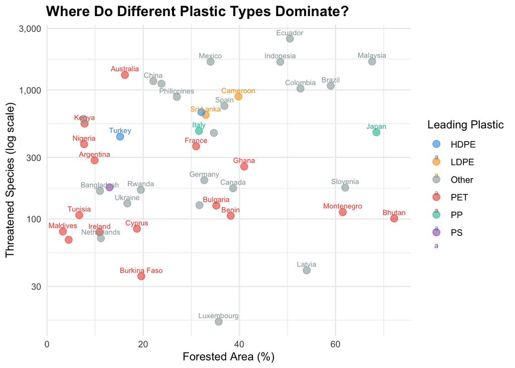

```r
plastic_ecology_summary_table |>
  ggplot(
    aes(x = avg_forested,
        y = avg_threatened,
        color = leading_plastic,
        label = country)
    )+
  geom_point(size = 3, alpha = 0.6) +
  geom_text(size = 2.5, check_overlap = TRUE, vjust = -0.7) +
  scale_y_log10(labels = scales::label_comma()) +
  scale_color_manual(
    values = c(
    "PET"   = "#E74C3C",
    "HDPE"  = "#3498DB",
    "LDPE"  = "#F39C12",
    "PP"    = "#18BC9C",
    "PS"    = "#9B59B6",
    "PVC"   = "#2C3E50",
    "Other" = "#95A5A6"
  )
  ) +
  labs(
    x = "Forested Area (%)",
    y = "Threatened Species (log scale)",
    color = "Leading Plastic",
    title = "Where Do Different Plastic Types Dominate?"
  ) +
  theme_minimal() +
  theme(plot.title = element_text(face = "bold", size = 14))
```

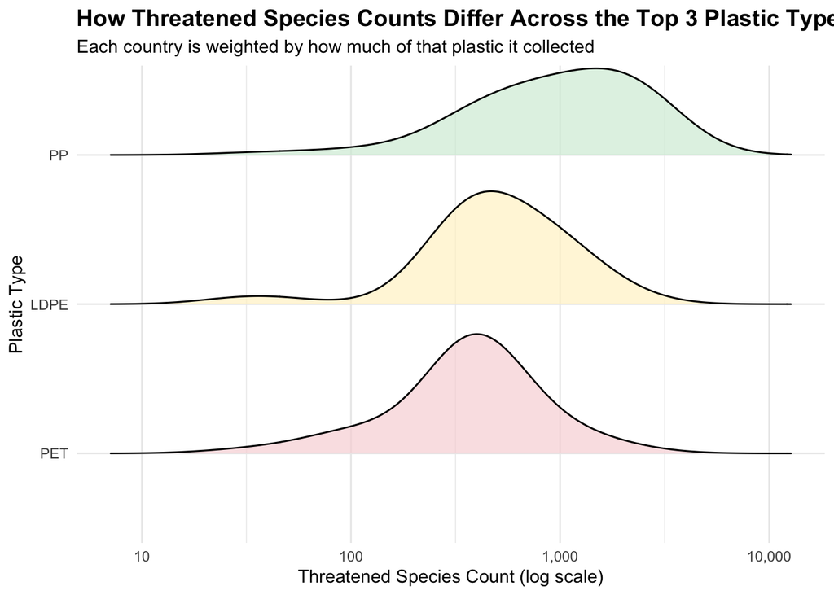

```r
# Identify the three most-collected plastic types in the data
top3_plastics <- population_plastics |>
  filter(parent_company == "Grand Total") |>
  summarize(across(c(pet, hdpe, ldpe, pp, ps, pvc),
                   ~ sum(.x, na.rm = TRUE))) |>
  pivot_longer(everything(),
               names_to = "plastic",
               values_to = "total") |>
  slice_max(total, n = 3) |>
  pull(plastic)

population_plastics |>
  filter(parent_company == "Grand Total",
         grand_total > 0,
         !is.na(threatened_species)) |>
  pivot_longer(cols = all_of(top3_plastics),
               names_to = "plastic_type",
               values_to = "count") |>
  filter(count > 0) |>
  mutate(plastic_type = factor(toupper(plastic_type),
                               levels = toupper(top3_plastics))) |>
  ggplot(aes(x = threatened_species,
             y = plastic_type,
             fill = plastic_type,
             weight = count)) +
  geom_density_ridges(scale = 0.8, alpha = 0.7) +
  scale_x_log10(labels = scales::label_comma()) +
  scale_fill_manual(values = c("#f8d7da", "#fff3cd", "#d4edda")) +
  labs(
    title = "How Threatened Species Counts Differ Across the Top 3 Plastic Types",
    subtitle = "Each country is weighted by how much of that plastic it collected",
    x = "Threatened Species Count (log scale)",
    y = "Plastic Type"
  ) +
  theme_minimal() +
  theme(
    plot.title = element_text(face = "bold", size = 14),
    plot.subtitle = element_text(size = 11),
    legend.position = "none"
  )
```

```r
pet_model <- population_plastics |>
  filter(parent_company == "Grand Total",
         grand_total > 0,
         !is.na(forested_area),
         !is.na(threatened_species),
         !is.na(gdp_per_capita),
         !is.na(volunteers)) |>
  mutate(pet_prop = pet / grand_total) |>
  lm(pet_prop ~ forested_area +
                log(threatened_species) +
                log(gdp_per_capita) +
                volunteers, data = _)

anova(pet_model) |>
  tidy() |>
  mutate(
    pct_variance = sumsq / sum(sumsq) * 100,
    term = recode(term,
      "volunteers"               = "Volunteers",
      "forested_area"            = "Forested Area",
      "log(threatened_species)"  = "Threatened Species (log)",
      "log(gdp_per_capita)"      = "GDP Per Capita (log)",
      "Residuals"                = "Unexplained")
  ) |>
  select(term, df, sumsq, pct_variance, statistic, p.value) |>
  gt() |>
  tab_header(
    title = "What Predicts PET Plastic Proportion?",
    subtitle = "Variance in PET proportion partitioned across ecological, economic and volunteer predictors"
  ) |>
  cols_label(
    term         = "Source",
    df           = "df",
    sumsq        = "Sum of Squares",
    pct_variance = "% of Variance",
    statistic    = "F",
    p.value      = "p-value"
  ) |>
  fmt_number(columns = c(sumsq, statistic), decimals = 3) |>
  fmt_number(columns = pct_variance, decimals = 1) |>
  fmt_number(columns = p.value, decimals = 4) |>
  sub_missing(missing_text = "—") |>
  tab_style(
    style = cell_text(weight = "bold"),
    locations = cells_column_labels()
  ) |>
  tab_style(
    style = list(cell_fill(color = "#18BC9C"),
                 cell_text(weight = "bold")),
    locations = cells_body(rows = p.value < 0.05)
  ) |>
  tab_options(
    column_labels.background.color = "#2C3E50",
    heading.background.color = "#2C3E50"
  ) |>
  tab_source_note(
    "Note: PET is modeled as it showed the strongest relationship with forest coverage and threatened species."
  ) |>
  tab_source_note(
    paste0("Model R² = ", round(summary(pet_model)$r.squared, 3),
           " · n = ", nobs(pet_model))
  )
```

What Predicts PET Plastic Proportion?

Variance in PET proportion partitioned across ecological, economic and volunteer predictors

| Source | df | Sum of Squares | % of Variance | F | p-value |
| --- | --- | --- | --- | --- | --- |
| Forested Area | 1 | 0.449 | 7.0 | 3.259 | 0.0794 |
| Threatened Species (log) | 1 | 0.805 | 12.5 | 5.841 | 0.0209 |
| GDP Per Capita (log) | 1 | 0.105 | 1.6 | 0.760 | 0.3892 |
| Volunteers | 1 | 0.136 | 2.1 | 0.990 | 0.3263 |
| Unexplained | 36 | 4.962 | 76.8 | — | — |

Note: PET is modeled as it showed the strongest relationship with forest coverage and threatened species.  
Model R² = 0.232 · n = 41